# Differential Expression - Microarray

CCDL for ALSF

September 2020

# 1 Purpose of this analysis

This notebook takes data and metadata from refine.bio and identifies differentially expressed genes.

⬇️ **Jump to the analysis code** ⬇️

# 2 How to run this example

For general information about our tutorials and the basic software packages you will need, please see our [‘Getting Started’ section](https://alexslemonade.github.io/refinebio-examples/01-getting-started/getting-started.html#how-this-tutorial-is-structured). We recommend taking a look at our [Resources for Learning R](https://alexslemonade.github.io/refinebio-examples/01-getting-started/getting-started.html#resources-for-learning-r) if you have not written code in R before.

## 2.1 Obtain the `.Rmd` file

To run this example yourself, [download the `.Rmd` for this analysis by clicking this link](https://alexslemonade.github.io/refinebio-examples/02-microarray/differential-expression_microarray_01.Rmd).

You can open this `.Rmd` file in RStudio and follow the rest of these steps from there. (See our [section about getting started with R notebooks](https://alexslemonade.github.io/refinebio-examples/01-getting-started/getting-started.html#how-to-get-and-use-rmds) if you are unfamiliar with `.Rmd` files.) Clicking this link will most likely send this to your downloads folder on your computer. Move this `.Rmd` file to where you would like this example and its files to be stored.

## 2.2 Set up your analysis folders

Good file organization is helpful for keeping your data analysis project on track! We have set up some code that will automatically set up a folder structure for you. Run this next chunk to set up your folders!

If you have trouble running this chunk, see our [introduction to using `.Rmd`s](https://alexslemonade.github.io/refinebio-examples/01-getting-started/getting-started.html#how-to-get-and-use-rmds) for more resources and explanations.

```r
# Create the data folder if it doesn't exist
if (!dir.exists("data")) {
  dir.create("data")
}

# Define the file path to the plots directory
plots_dir <- "plots" # Can replace with path to desired output plots directory

# Create the plots folder if it doesn't exist
if (!dir.exists(plots_dir)) {
  dir.create(plots_dir)
}

# Define the file path to the results directory
results_dir <- "results" # Can replace with path to desired output results directory

# Create the results folder if it doesn't exist
if (!dir.exists(results_dir)) {
  dir.create(results_dir)
}
```

In the same place you put this `.Rmd` file, you should now have three new empty folders called `data`, `plots`, and `results`!

## 2.3 Obtain the dataset from refine.bio

For general information about downloading data for these examples, see our [‘Getting Started’ section](https://alexslemonade.github.io/refinebio-examples/01-getting-started/getting-started.html#how-to-get-the-data).

Go to this [dataset’s page on refine.bio](https://www.refine.bio/experiments/GSE71270/creb-overexpression-induces-leukemia-in-zebrafish-by-blocking-myeloid-differentiation-process).

Click the “Download Now” button on the right side of this screen.

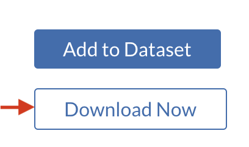

Fill out the pop up window with your email and our Terms and Conditions:

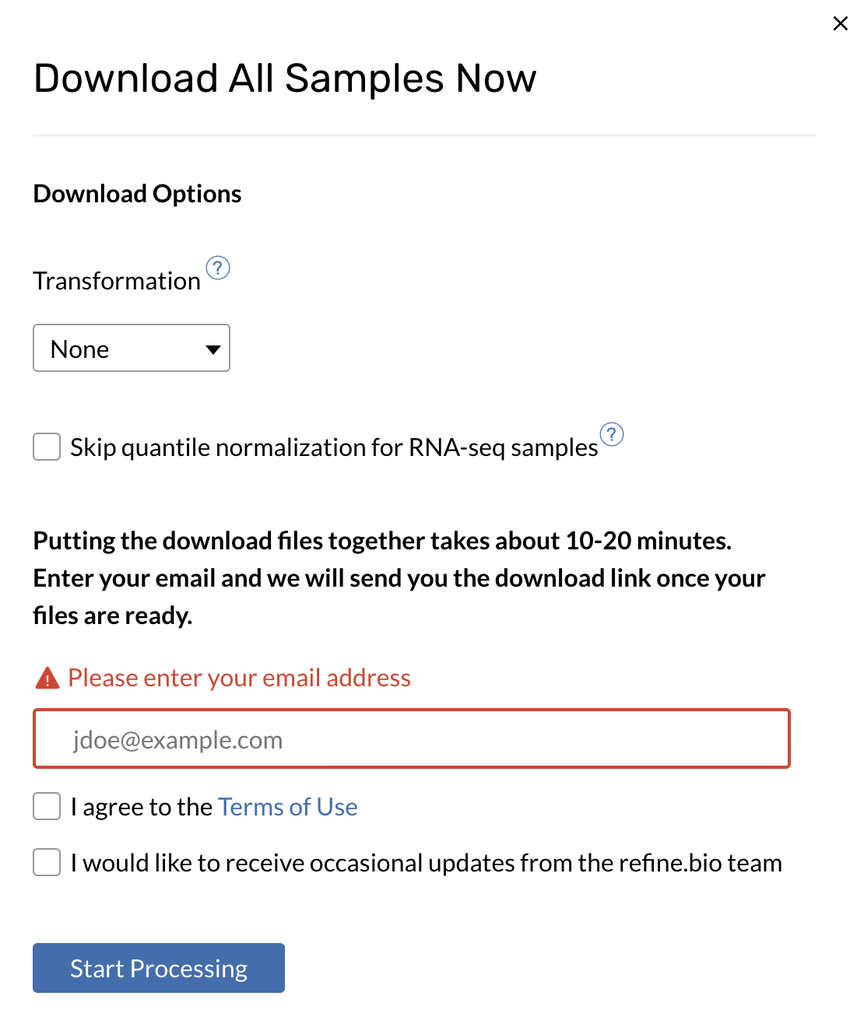

It may take a few minutes for the dataset to process. You will get an email when it is ready.

## 2.4 About the dataset we are using for this example

For this example analysis, we will use this [CREB overexpression zebrafish](https://www.refine.bio/experiments/GSE71270/creb-overexpression-induces-leukemia-in-zebrafish-by-blocking-myeloid-differentiation-process). Tregnago *et al.* (2016) measured microarray gene expression of zebrafish samples overexpressing human CREB, as well as control samples. In this analysis, we will test differential expression between the control and CREB-overexpressing groups.

## 2.5 Place the dataset in your new `data/` folder

refine.bio will send you a download button in the email when it is ready. Follow the prompt to download a zip file that has a name with a series of letters and numbers and ends in `.zip`. Double clicking should unzip this for you and create a folder of the same name.

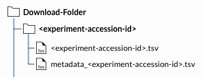

For more details on the contents of this folder see [these docs on refine.bio](http://docs.refine.bio/en/latest/main_text.html#downloadable-files).

The `<experiment_accession_id>` folder has the data and metadata TSV files you will need for this example analysis. Experiment accession ids usually look something like `GSE1235` or `SRP12345`.

Copy and paste the `GSE71270` folder into your newly created `data/` folder.

## 2.6 Check out our file structure!

Your new analysis folder should contain:

- The example analysis Rmd you downloaded
- A folder called “data” which contains:
  - The `GSE71270` folder which contains:
    - The gene expression
    - The metadata TSV
- A folder for `plots` (currently empty)
- A folder for `results` (currently empty)

Your example analysis folder should now look something like this (except with respective experiment accession id and analysis notebook name you are using):

[figure not shown]

In order for our example here to run without a hitch, we need these files to be in these locations so we’ve constructed a test to check before we get started with the analysis. Run this chunk to double check that your files are in the right place.

```r
# Define the file path to the data directory
data_dir <- file.path("data", "GSE71270")

# Check if the gene expression matrix file is in the data directory stored as `data_dir`
file.exists(file.path(data_dir, "GSE71270.tsv"))
```

```
## [1] TRUE
```

```r
# Check if the metadata file is in the data directory stored as `data_dir`
file.exists(file.path(data_dir, "metadata_GSE71270.tsv"))
```

```
## [1] TRUE
```

If the chunk above printed out `FALSE` to either of those tests, you won’t be able to run this analysis *as is* until those files are in the appropriate place.

If the concept of a “file path” is unfamiliar to you; we recommend taking a look at our [section about file paths](https://alexslemonade.github.io/refinebio-examples/01-getting-started/getting-started.html#an-important-note-about-file-paths-and-Rmds).

# 3 Using a different refine.bio dataset with this analysis?

If you’d like to adapt an example analysis to use a different dataset from [refine.bio](https://www.refine.bio/), we recommend placing the files in the `data/` directory you created and changing the filenames and paths in the notebook to match these files (we’ve put comments to signify where you would need to change the code). We suggest saving plots and results to `plots/` and `results/` directories, respectively, as these are automatically created by the notebook. From here you can customize this analysis example to fit your own scientific questions and preferences.

# 4 Differential Expression - Microarray

## 4.1 Install libraries

See our Getting Started page with [instructions for package installation](https://alexslemonade.github.io/refinebio-examples/01-getting-started/getting-started.html#what-you-need-to-install) for a list of the other software you will need, as well as more tips and resources.

```r
if (!("limma" %in% installed.packages())) {
  # Install this package if it isn't installed yet
  BiocManager::install("limma", update = FALSE)
}
if (!("EnhancedVolcano" %in% installed.packages())) {
  # Install this package if it isn't installed yet
  BiocManager::install("EnhancedVolcano", update = FALSE)
}
if (!("apeglm" %in% installed.packages())) {
  # Install this package if it isn't installed yet
  BiocManager::install("apeglm", update = FALSE)
}
```

Attach the packages we need for this analysis.

```r
# Attach the library
library(limma)

# We will need this so we can use the pipe: %>%
library(magrittr)

# We'll use this for plotting
library(ggplot2)
```

## 4.2 Import and set up data

Data downloaded from refine.bio include a metadata tab separated values (TSV) file and a data TSV file. This chunk of code will read the both TSV files and add them as data frames to your environment.

```r
# Read in metadata TSV file
metadata <- readr::read_tsv(file.path(
  data_dir, # Replace with path to your metadata file
  "metadata_GSE71270.tsv" # Replace with the name of your metadata file
))
# Read in data TSV file
df <- readr::read_tsv(file.path(
  data_dir, # Replace with path to your data file
  "GSE71270.tsv" # Replace with the name of your data file
)) %>%
  # Tuck away the Gene id column as rownames
  tibble::column_to_rownames("Gene")
```

Let’s ensure that the metadata and data are in the same sample order.

```r
# Make the data in the order of the metadata
df <- df %>%
  dplyr::select(metadata$geo_accession)

# Check if this is in the same order
all.equal(colnames(df), metadata$geo_accession)
```

```
## [1] TRUE
```

## 4.3 Set up design matrix

The `genotype/variation` column contains group information we will be using for differential expression. But the `/` it contains in its column name makes it more annoying to access.  
Accessing variable that have names with special characters like `/`, or spaces, require extra work-arounds to ignore R’s normal interpretations of these characters.

```r
metadata <- metadata %>%
  dplyr::rename("genotype" = `genotype/variation`) # This step will not be the same (or might not be needed at all) with a different dataset
```

Now we will create a model matrix based on our newly renamed `genotype` variable.

```r
# Create the design matrix from the genotype information
des_mat <- model.matrix(~ metadata$genotype)
```

## 4.4 Perform differential expression

After applying our data to linear model, in this example we apply empirical Bayes smoothing and Benjamini-Hochberg multiple testing correction. The `topTable()` function default is to use Benjamini-Hochberg but this can be changed to a different method using the `adjust.method` argument (see the `?topTable` help page for more about the options).

```r
# Apply linear model to data
fit <- lmFit(df, design = des_mat)

# Apply empirical Bayes to smooth standard errors
fit <- eBayes(fit)

# Apply multiple testing correction and obtain stats
stats_df <- topTable(fit, number = nrow(df)) %>%
  tibble::rownames_to_column("Gene")
```

```
## Removing intercept from test coefficients
```

Let’s take a peek at what our results table looks like.

```r
head(stats_df)
```

```
##                 Gene      logFC   AveExpr         t      P.Value    adj.P.Val
## 1 ENSDARG00000104315  0.9797633 0.5623370  20.22172 2.965470e-09 2.735943e-05
## 2 ENSDARG00000101341 -0.6505860 1.0051319 -15.88369 2.895358e-08 1.335629e-04
## 3 ENSDARG00000034503  0.9219813 0.6515454  14.48634 6.842701e-08 1.875194e-04
## 4 ENSDARG00000014945  0.5699025 0.7756560  13.88657 1.013543e-07 1.875194e-04
## 5 ENSDARG00000019113 -0.6196192 0.8643650 -13.88257 1.016255e-07 1.875194e-04
## 6 ENSDARG00000005799 -0.9383565 1.1067382 -12.51418 2.648122e-07 3.651949e-04
##           B
## 1 11.031530
## 2  9.305940
## 3  8.593576
## 4  8.258341
## 5  8.256041
## 6  7.415053
```

By default, results are ordered by largest `B` (the log odds value) to the smallest, which means your most differentially expressed genes should be toward the top.

See the help page by using `?topTable` for more information and options for this table.

## 4.5 Check results by plotting one gene

To test if these results make sense, we can make a plot of one of top genes. Let’s try extracting the data for `ENSDARG00000104315` and set up its own data frame for plotting purposes.

```r
top_gene_df <- df %>%
  # Extract this gene from `df`
  dplyr::filter(rownames(.) == "ENSDARG00000104315") %>%
  # Transpose so the gene is a column
  t() %>%
  # Transpose made this a matrix, let's make it back into a data.frame like before
  data.frame() %>%
  # Store the sample ids as their own column instead of being row names
  tibble::rownames_to_column("refinebio_accession_code") %>%
  # Join on the selected columns from metadata
  dplyr::inner_join(dplyr::select(
    metadata,
    refinebio_accession_code,
    genotype
  ))
```

Let’s take a sneak peek at what our `top_gene_df` looks like.

```r
top_gene_df
```

```
##    refinebio_accession_code ENSDARG00000104315                      genotype
## 1                GSM1831679         1.02455053 overexpressing the human CREB
## 2                GSM1831681         0.16873806                       control
## 3                GSM1831680         0.09432761                       control
## 4                GSM1831676         1.12625586 overexpressing the human CREB
## 5                GSM1831684        -0.04516550                       control
## 6                GSM1831683         0.05877268                       control
## 7                GSM1831682         0.08560404                       control
## 8                GSM1831675         1.03729982 overexpressing the human CREB
## 9                GSM1831677         1.11066483 overexpressing the human CREB
## 10               GSM1831678         0.96232255 overexpressing the human CREB
```

Now let’s plot the data for `ENSDARG00000104315` using our `top_gene_df`.

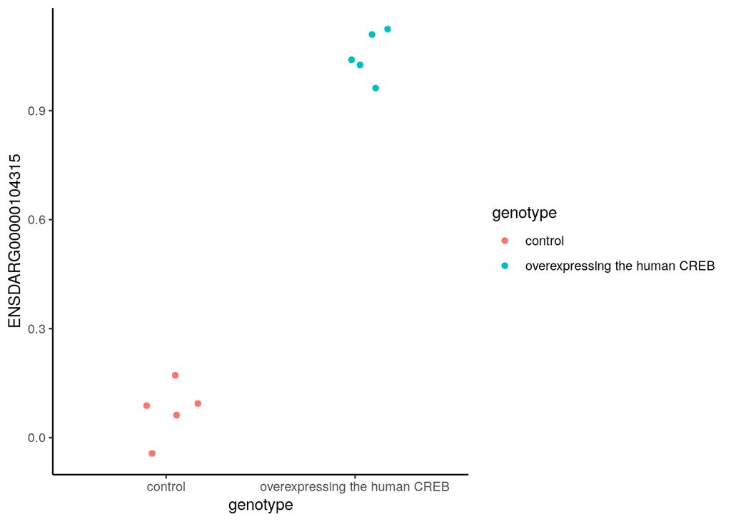

```r
ggplot(top_gene_df, aes(x = genotype, y = ENSDARG00000104315, color = genotype)) +
  geom_jitter(width = 0.2) + # We'll make this a jitter plot
  theme_classic() # This makes some aesthetic changes
```

These results make sense. The overexpressing CREB group samples have much higher expression values for ENSDARG00000104315 than the control samples do.

## 4.6 Write results to file

The results in `stats_df` will be saved to our `results/` directory.

```r
readr::write_tsv(stats_df, file.path(
  results_dir,
  "GSE71270_limma_results.tsv" # Replace with a relevant output name
))
```

## 4.7 Make a volcano plot

```r
EnhancedVolcano::EnhancedVolcano(stats_df,
  lab = stats_df$Gene, # This has to be a vector with our labels we want for our genes
  x = "logFC", # This is the column name in `stats_df` that contains what we want on the x axis
  y = "adj.P.Val" # This is the column name in `stats_df` that contains what we want on the y axis
)
```

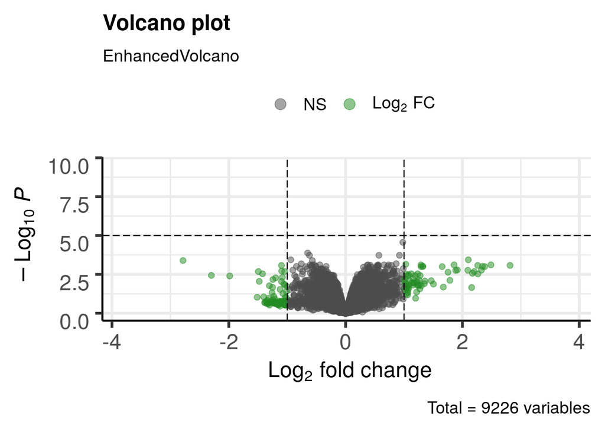

In this plot, green points represent genes that meet the log2 fold change, by default the cutoff is absolute value of 1.  
But there are no genes that meet the p value cutoff, which by default is `1e-05`. We used the adjusted p values for our plot above, so you may want to adjust this with the `pCutoff` argument (Take a look at all the options for tailoring this plot using `?EnhancedVolcano`).

Let’s make the same plot again, but adjust the `pCutoff` since we are using multiple-testing corrected p values, and this time we will assign the plot to our environment as `volcano_plot`.

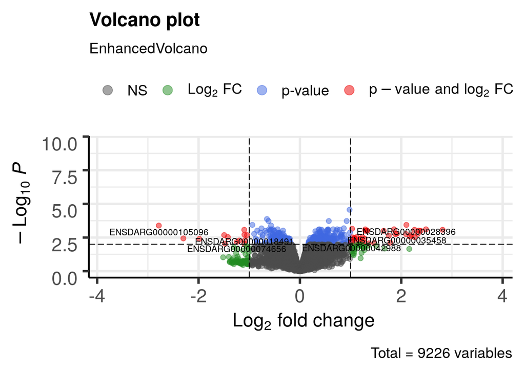

```r
volcano_plot <- EnhancedVolcano::EnhancedVolcano(stats_df,
  lab = stats_df$Gene,
  x = "logFC",
  y = "adj.P.Val",
  pCutoff = 0.01 # Because we are using adjusted p values, we can loosen this a bit
)

# Print out our plot
volcano_plot
```

Let’s save this plot to a PNG file.

```r
ggsave(
  plot = volcano_plot,
  file.path(plots_dir, "GSE71270_volcano_plot.png")
) # Replace with a plot name relevant to your data
```

# 5 Resources for further learning

- [The full users guide on limma](https://bioconductor.org/packages/release/bioc/vignettes/limma/inst/doc/usersguide.pdf) shows examples of limma functions for different experimental models (Ritchie *et al.* 2015).
- [A general guide to differential expression, including a section about interpreting results](http://www.nathalievialaneix.eu/doc/pdf/tutorial-rnaseq.pdf) (Gonzalez 2014).
- [End to End workflow for Affymetrix microarray data](https://www.bioconductor.org/packages/devel/workflows/vignettes/maEndToEnd/inst/doc/MA-Workflow.html) (Klaus and Reisenauer 2018).
- [The `EnhancedVolcano` vignette](https://www.bioconductor.org/packages/release/bioc/vignettes/EnhancedVolcano/inst/doc/EnhancedVolcano.html) has more examples on how to tailor your volcano plot (Blighe *et al.* 2020).

# 6 Session info

At the end of every analysis, before saving your notebook, we recommend printing out your session info. This helps make your code more reproducible by recording what versions of softwares and packages you used to run this.

[session information not shown]

Blighe K., S. Rana, and M. Lewis, 2020 *EnhancedVolcano: Publication-ready volcano plots with enhanced colouring and labeling*.

Gonzalez I., 2014 *Statistical analysis of rna-seq data*.

Klaus B., and S. Reisenauer, 2018 *An end to end workflow for differential gene expression using affymetrix microarrays*.

Ritchie M. E., B. Phipson, D. Wu, Y. Hu, and C. W. Law *et al.*, 2015 limma powers differential expression analyses for RNA-sequencing and microarray studies. Nucleic Acids Research 43: e47. https://doi.org/10.1093/nar/gkv007

Tregnago C., E. Manara, M. Zampini, V. Bisio, and C. Borga *et al.*, 2016 CREB engages C/EBPÎ´ to initiate leukemogenesis. Leukemia 30: 1887–1896.

Zhu A., J. G. Ibrahim, and M. I. Love, 2018 Heavy-tailed prior distributions for sequence count data: Removing the noise and preserving large differences. Bioinformatics. https://doi.org/10.1093/bioinformatics/bty895